# Indicators For Upcoming Economic “Crash”?

[SOURCE: U.S. Bureau of Labor Statistics - Current Employment Statistics](https://download.bls.gov/pub/time.series/ce/ce.series)

**NOTE:** This html page is being updated every 1st Friday of each month

Because of their volatility, I decided not to use stock market or investment trends as indicators of the overall health of the economy and looked instead at indicators related to job growth. It seems reasonable to believe that when the economy is doing well, job growth should be steady or increasing, and when it is not, we should expect declining job growth. Using data from the U.S. Bureau of Labor Statistics, we can obtain various measures related to job growth or the lack thereof.

### Total # of People Employed from 2007 thru 2026 so that we can include 2008-2009 Recession Period, Pre-COVID, COVID, and recent data

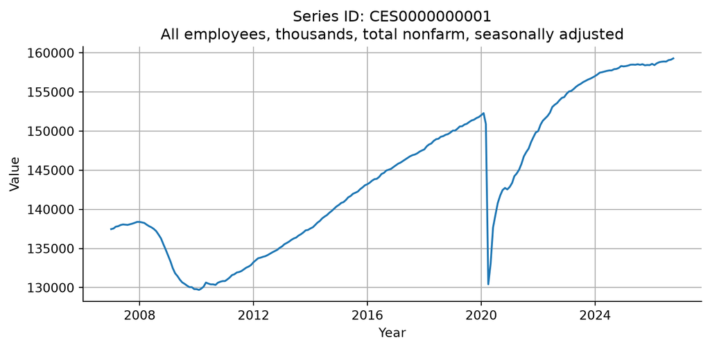

```
Last 13 recent months of data - values are in thousands
```

| year_month | value | monthly_change |
| --- | --- | --- |
| 2025-10-01 | 158408.0 |  |
| 2025-11-01 | 158449.0 |  |
| 2025-12-01 | 158432.0 |  |
| 2026-01-01 | 158592.0 |  |
| 2026-02-01 | 158436.0 |  |
| 2026-03-01 | 158650.0 |  |
| 2026-04-01 | 158798.0 |  |
| 2026-05-01 | 158861.0 |  |
| 2026-06-01 | 158892.0 |  |
| 2026-07-01 | 158882.0 |  |
| 2026-08-01 | 159068.0 |  |
| 2026-09-01 | 159128.0 |  |
| 2026-10-01 | 159293.0 |  |

By just looking at the slope of the figure above, we can see that starting with early 2024, the job growth is far worse compared to pre-COVID.

## Now, let’s look at difference or change in total employment numbers on a monthly basis (“monthly_change”)

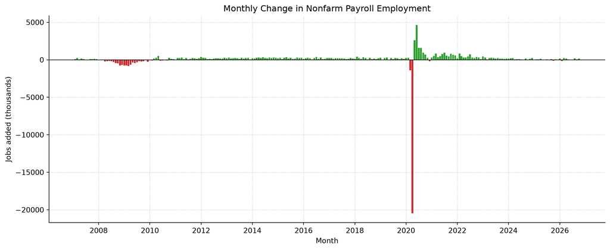

#### From above, due to the extreme values, it is hard to visually compare. So, let’s exclude the years of extreme data points (2020 thru 2023). So let’s combine a data set containing only 2017 thru 2019 data with another data set contaning 2024 thru 2026 data. This data set we would consider a “normal” or “steady-state” of activity.

[interactive chart not shown]

**From above, we see it is now easier to visually compare. We can immediately see that 2025 was a terrible year for job growth. Things look to be improving after summer of 2026.**

### Let’s look at private sector employment

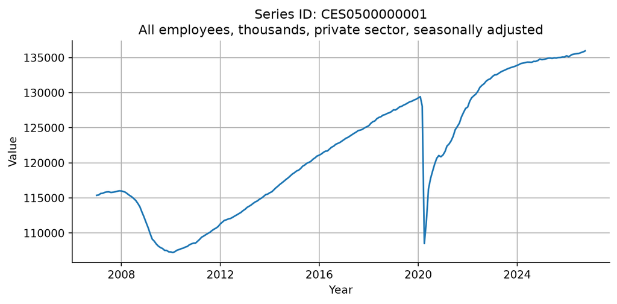

```
Last 13 recent months of data
```

| year_month | value | monthly_change |
| --- | --- | --- |
| 2025-10-01 | 135018.0 |  |
| 2025-11-01 | 135090.0 |  |
| 2025-12-01 | 135083.0 |  |
| 2026-01-01 | 135263.0 |  |
| 2026-02-01 | 135115.0 |  |
| 2026-03-01 | 135317.0 |  |
| 2026-04-01 | 135467.0 |  |
| 2026-05-01 | 135528.0 |  |
| 2026-06-01 | 135554.0 |  |
| 2026-07-01 | 135582.0 |  |
| 2026-08-01 | 135724.0 |  |
| 2026-09-01 | 135802.0 |  |
| 2026-10-01 | 135961.0 |  |

[interactive chart not shown]

#### Average and median monthly change from 2017 thru 2019 of **all non-farm** employment:

```python
(
    GT(
        df_all
        .filter(
            pl.col("year").is_in(["2017","2018","2019"])
        )
        .select(
            pl.col("monthly_change").mean().alias("avg_value"),
            pl.col("monthly_change").median().alias("median_value")
        )
    )
    .fmt_number(columns="avg_value", decimals=2)
    .cols_align(align="center")
    .show()
)
```

| avg_value | median_value |
| --- | --- |
| 177.39 | 194.0 |

#### Average and median monthly change from 2024 thru 2026 of **all non-farm** employment:

```python
(
    GT(
        df_all
        .filter(
            pl.col("year").is_in(["2024","2025","2026"])
        )
        .select(
            pl.col("monthly_change").mean().alias("avg_value"),
            pl.col("monthly_change").median().alias("median_value")
        )
    )
    .fmt_number(columns="avg_value", decimals=2)
    .cols_align(align="center")
    .show()
)
```

| avg_value | median_value |
| --- | --- |
| 71.65 | 64.0 |

Pre-COVID, job growth was approximately 2.5 times better than 2024 through 2026.

#### Average and median monthly change from 2017 thru 2019 of **all private sector** employment:

```python
(
    GT(
        df_private
        .filter(
            pl.col("year").is_in(["2017","2018","2019"])
        )
        .select(
            pl.col("monthly_change").mean().alias("avg_value"),
            pl.col("monthly_change").median().alias("median_value")
        )
    )
    .fmt_number(columns="avg_value", decimals=2)
    .cols_align(align="center")
    .show()
)
```

| avg_value | median_value |
| --- | --- |
| 165.67 | 171.5 |

#### Average and median monthly change from 2024 thru 2026 of **all private sector** employment:

```python
(
    GT(
        df_private
        .filter(
            pl.col("year").is_in(["2024","2025","2026"])
        )
        .select(
            pl.col("monthly_change").mean().alias("avg_value"),
            pl.col("monthly_change").median().alias("median_value")
        )
    )
    .fmt_number(columns="avg_value", decimals=2)
    .cols_align(align="center")
    .show()
)
```

| avg_value | median_value |
| --- | --- |
| 64.56 | 66.0 |

Looking at just private-sector employment, pre-COVID had seen job growth of at least 2.5 times higher than 2024-through 2026.

## Let’s take population into account of employment-eligible persons (16 years old and over) using series ID “LNS12300000”

[SOURCE: U.S. Bureau of Labor Statistics - National Unemployment](https://download.bls.gov/pub/time.series/ln/ln.series)

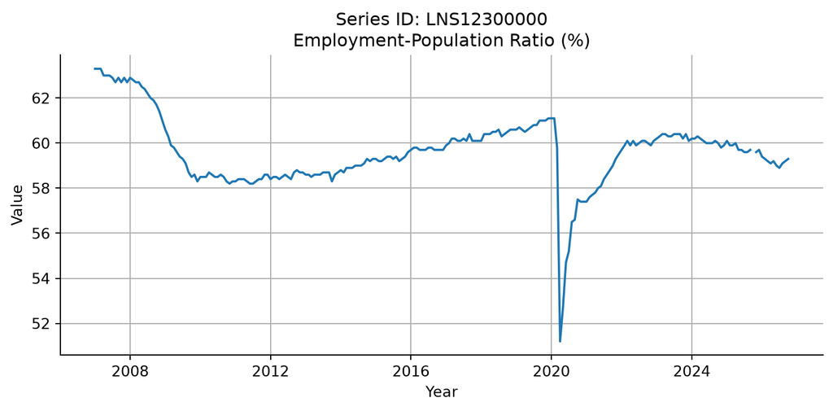

```
Last 13 recent months of data
```

| year_month | value |
| --- | --- |
| 2025-10-01 | None |
| 2025-11-01 | 59.6 |
| 2025-12-01 | 59.7 |
| 2026-01-01 | 59.4 |
| 2026-02-01 | 59.3 |
| 2026-03-01 | 59.2 |
| 2026-04-01 | 59.1 |
| 2026-05-01 | 59.2 |
| 2026-06-01 | 59.0 |
| 2026-07-01 | 58.9 |
| 2026-08-01 | 59.1 |
| 2026-09-01 | 59.2 |
| 2026-10-01 | 59.3 |

When taking into account population level, we are at a downward trend since 2024. Population has been increasing since then. So to see a downward trend is concerning. Pre-COVID, the trend was upwards. In recent months of 2026, we are trending upwards. But, it is unknown if upward trend will continue.

# Let’s look at a few more metrics

## Layoffs and Discharges

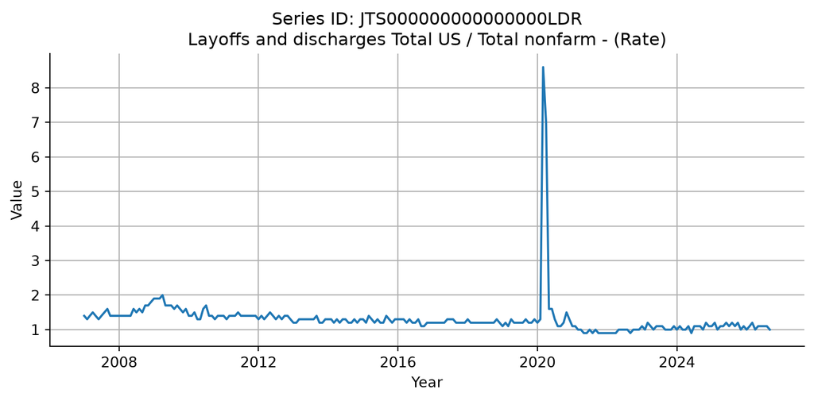

## Hires

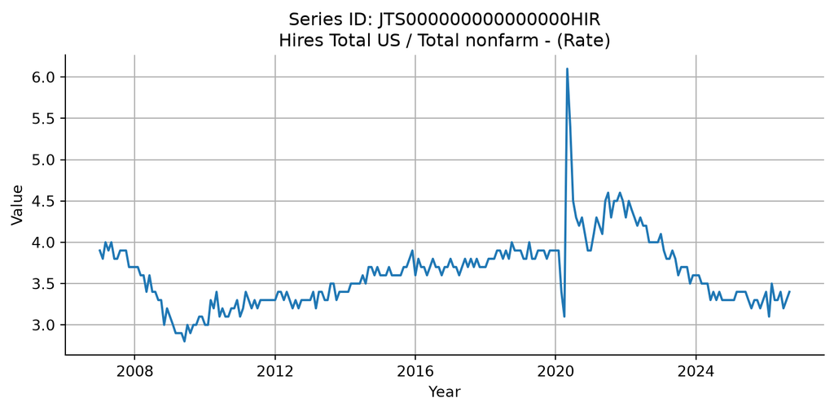

## Job Openings

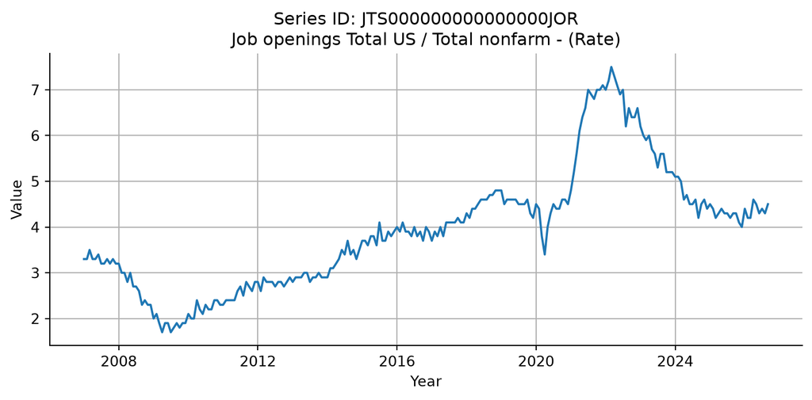

Layoffs and discharges don’t look too alarming. The number of hires and job openings in recent months are showing signs of improvment.

There has been speculation that job openings are over-inflated due to supposedly fake job postings. If that is the case, then the hires figure probably holds more weight. The hires figure paints a very bleak outlook even though there was some uptick in 2026.

## Summary

From the figures above, 2025 was a terrible year for job growth, with some uptick in 2026. Whether the upward trend will extend into 2027 remains to be seen.

Some will argue that the decline in job growth is due to LLMs/AI. But the very first figure showed that job growth had already slowed drastically starting in early 2024. The capabilities of LLMs did not reach impressive levels until the beginning of 2026. Furthermore, it takes companies a significant amount of time to adopt new technologies, often at least 1 to 3 years.

Looking at past recessions, they have occurred every 10 to 15 years. Some economic experts speculated that we were due for a recession in 2019, since the last one occurred in 2008/2009. But COVID delayed it.

Based on the figures above, I would say we are in an economic recession (or whatever negative economic labeling you want to use) starting in 2024. There has been an uptick in hiring in late 2026, but I think that is related to AI investments, not job growth outside of AI, healthcare, and education.